# Parkinson’s Classification Ensemble

DA5030 / Decision Tree & Logistic Regression Classification

Zoe Chow

Summer 2025

#### *The goal of this project is to develop an ensemble model that combines a random forest and a logistic regression classifier to predict Parkinson’s disease diagnoses based on patients’ medical histories.*

## Load Packages and CSV

```r
library(dplyr)
library(ggplot2)
library(kableExtra)
library(knitr)
library(caret)
library(randomForest)
```

```r
train_url <- "https://s3.us-east-2.amazonaws.com/artificium.us/datasets/parkinsons-diagnostic-data.csv"

train_df <- read.csv(train_url, stringsAsFactors = F, header = T)
```

## Data Preparation

To prepare the data for random forest and logistic regression modeling, we will begin by examining the dataset and removing any irrelevant or unnecessary features. Next, we will apply appropriate transformations and assessments to ensure the data is well-suited for both model types. Finally, we will split the data into training and testing sets to support effective model development and evaluation.

### Exploratory Data Analysis (EDA)

```r
head(train_df)
```

|  | PatientID | Age | Gender | Ethnicity | EducationLevel | BMI | Smoking | AlcoholConsumption | PhysicalActivity | DietQuality | SleepQuality | FamilyHistoryParkinsons | TraumaticBrainInjury | Hypertension | Diabetes | Depression | Stroke | SystolicBP | DiastolicBP | CholesterolTotal | CholesterolLDL | CholesterolHDL | CholesterolTriglycerides | UPDRS | MoCA | FunctionalAssessment | Tremor | Rigidity | Bradykinesia | … |
| --- | --- | --- | --- | --- | --- | --- | --- | --- | --- | --- | --- | --- | --- | --- | --- | --- | --- | --- | --- | --- | --- | --- | --- | --- | --- | --- | --- | --- | --- | --- |
| 1 | 3058 | 85 | Female | NA | High School | 19.61988 | 0 | 5.108241 | 1.380660 | 3.893969 | 9.283194 | 0 | 0 | 0 | 0 | 0 | 0 | 129 | 60 | 222.8423 | 148.12562 | 37.86778 | 337.3071 | 6.458713 | 29.181289 | 1.5724272 | 1 | 0 | 0 | … |
| 2 | 3059 | 75 | Female | NA | College | 16.24734 | 1 | 6.027648 | 8.409804 | 8.513428 | 5.602470 | 0 | 0 | 0 | 0 | 0 | 0 | 163 | 76 | 210.5011 | 153.75646 | 77.22812 | 264.6355 | 37.306703 | 12.332639 | 4.7875513 | 0 | 1 | 0 | … |
| 3 | 3061 | 52 | Female | NA | None | 15.45456 | 0 | 5.997788 | 1.375045 | 6.715033 | 4.196189 | 0 | 0 | 0 | 0 | 0 | 0 | 146 | 78 | 280.3395 | 136.29919 | 51.86963 | 362.1897 | 52.964696 | 21.304268 | 3.3912877 | 1 | 1 | 1 | … |
| 4 | 3062 | 87 | Female | NA | High School | 18.61604 | 0 | 9.775243 | 1.188607 | 4.657572 | 9.363925 | 0 | 0 | 0 | 0 | 0 | 0 | 115 | 94 | 284.0142 | 108.44945 | 25.06942 | 149.9566 | 21.804880 | 8.336364 | 3.2009693 | 0 | 0 | 0 | … |
| 5 | 3064 | 78 | Female | NA | None | 30.54200 | 1 | 2.011281 | 9.028536 | 9.838446 | 5.981984 | 0 | 0 | 1 | 0 | 0 | 0 | 122 | 60 | 283.5030 | 145.80141 | 64.04567 | 319.8548 | 37.453720 | 17.432685 | 0.5027474 | 1 | 0 | 0 | … |
| 6 | 3065 | 70 | Female | NA | None | 36.75828 | 1 | 19.988866 | 3.891749 | 3.421960 | 7.895866 | 0 | 0 | 0 | 1 | 0 | 0 | 129 | 99 | 185.2037 | 67.92444 | 25.02764 | 390.3444 | 181.172565 | 11.065216 | 1.1906109 | 1 | 0 | 0 | … |

```r
str(train_df)
```

```
## 'data.frame':    2005 obs. of  34 variables:
##  $ PatientID               : int  3058 3059 3061 3062 3064 3065 3066 3067 3068 3069 ...
##  $ Age                     : int  85 75 52 87 78 70 80 71 70 53 ...
##  $ Gender                  : chr  "Female" "Female" "Female" "Female" ...
##  $ Ethnicity               : logi  NA NA NA NA NA NA ...
##  $ EducationLevel          : chr  "High School" "College" "None" "High School" ...
##  $ BMI                     : num  19.6 16.2 15.5 18.6 30.5 ...
##  $ Smoking                 : int  0 1 0 0 1 1 1 1 0 1 ...
##  $ AlcoholConsumption      : num  5.11 6.03 6 9.78 2.01 ...
##  $ PhysicalActivity        : num  1.38 8.41 1.38 1.19 9.03 ...
##  $ DietQuality             : num  3.89 8.51 6.72 4.66 9.84 ...
##  $ SleepQuality            : num  9.28 5.6 4.2 9.36 5.98 ...
##  $ FamilyHistoryParkinsons : int  0 0 0 0 0 0 0 0 0 0 ...
##  $ TraumaticBrainInjury    : int  0 0 0 0 0 0 0 1 0 0 ...
##  $ Hypertension            : int  0 0 0 0 1 0 0 0 0 0 ...
```

[output cut: 20 more lines]

```r
summary(train_df)
```

```
##    PatientID         Age          Gender          Ethnicity
##  Min.   :3058   Min.   :50.0   Length:2005        Mode:logical
##  1st Qu.:3584   1st Qu.:60.0   Class :character   NA's:2005
##  Median :4112   Median :70.0   Mode  :character
##  Mean   :4111   Mean   :69.7
##  3rd Qu.:4635   3rd Qu.:80.0
##  Max.   :5162   Max.   :89.0
##
##  EducationLevel          BMI           Smoking       AlcoholConsumption
##  Length:2005        Min.   :15.01   Min.   :0.0000   Min.   : 0.003563
##  Class :character   1st Qu.:20.79   1st Qu.:0.0000   1st Qu.: 5.125067
##  Mode  :character   Median :27.22   Median :0.0000   Median :10.120981
##                     Mean   :27.22   Mean   :0.2983   Mean   :10.062599
##                     3rd Qu.:33.50   3rd Qu.:1.0000   3rd Qu.:14.912089
##                     Max.   :40.00   Max.   :1.0000   Max.   :19.988866
##
##  PhysicalActivity    DietQuality        SleepQuality    FamilyHistoryParkinsons
##  Min.   :0.004157   Min.   :0.000011   Min.   : 4.013   Min.   :0.0000
##  1st Qu.:2.489607   1st Qu.:2.430635   1st Qu.: 5.487   1st Qu.:0.0000
##  Median :5.031550   Median :4.784695   Median : 6.936   Median :0.0000
##  Mean   :5.030945   Mean   :4.874636   Mean   : 7.000   Mean   :0.1436
##  3rd Qu.:7.567005   3rd Qu.:7.281984   3rd Qu.: 8.566   3rd Qu.:0.0000
##  Max.   :9.995255   Max.   :9.995864   Max.   :10.000   Max.   :1.0000
##                                        NA's   :4
##  TraumaticBrainInjury  Hypertension       Diabetes        Depression
##  Min.   :0.0000       Min.   :0.0000   Min.   :0.0000   Min.   :0.0
##  1st Qu.:0.0000       1st Qu.:0.0000   1st Qu.:0.0000   1st Qu.:0.0
##  Median :0.0000       Median :0.0000   Median :0.0000   Median :0.0
##  Mean   :0.1052       Mean   :0.1436   Mean   :0.1501   Mean   :0.2
##  3rd Qu.:0.0000       3rd Qu.:0.0000   3rd Qu.:0.0000   3rd Qu.:0.0
##  Max.   :1.0000       Max.   :1.0000   Max.   :1.0000   Max.   :1.0
##
##      Stroke          SystolicBP     DiastolicBP     CholesterolTotal
##  Min.   :0.00000   Min.   : 90.0   Min.   : 60.00   Min.   :150.1
##  1st Qu.:0.00000   1st Qu.:110.0   1st Qu.: 75.00   1st Qu.:189.0
##  Median :0.00000   Median :133.0   Median : 90.00   Median :228.4
##  Mean   :0.04788   Mean   :133.6   Mean   : 90.13   Mean   :226.6
##  3rd Qu.:0.00000   3rd Qu.:157.0   3rd Qu.:105.00   3rd Qu.:264.5
##  Max.   :1.00000   Max.   :179.0   Max.   :119.00   Max.   :300.0
##
```

[output cut: 17 more lines]

```
##  Min.   :0.0000   Min.   :0.0000      Min.   :0.0000   Min.   :0.0000
##  1st Qu.:0.0000   1st Qu.:0.0000      1st Qu.:0.0000   1st Qu.:0.0000
##  Median :0.0000   Median :0.0000      Median :0.0000   Median :0.0000
##  Mean   :0.2085   Mean   :0.1392      Mean   :0.2953   Mean   :0.2459
##  3rd Qu.:0.0000   3rd Qu.:0.0000      3rd Qu.:1.0000   3rd Qu.:0.0000
##  Max.   :1.0000   Max.   :1.0000      Max.   :1.0000   Max.   :1.0000
##
##   Constipation      Diagnosis
##  Min.   :0.0000   Min.   :0.0000
##  1st Qu.:0.0000   1st Qu.:0.0000
##  Median :0.0000   Median :1.0000
##  Mean   :0.2983   Mean   :0.6195
##  3rd Qu.:1.0000   3rd Qu.:1.0000
##  Max.   :1.0000   Max.   :1.0000
##
```

Random forest and logistic regression process data differently. While random forests are robust to noisy data and unscaled features, logistic regression is more sensitive to such issues and therefore requires cleaner, scaled input. As a result, different preprocessing transformations are necessary for each algorithm.

However, to properly build an ensemble model combining both algorithms, it is essential that all models are trained on the same set of samples. This means the datasets used for training must contain the same rows, even if feature transformations differ.

To prepare the data, I will first remove the `Ethnicity` column because it contains only missing values. The `PatientID` column will also be removed, as it is merely an identifier and does not contribute to the diagnosis. I will drop the 4 rows with missing values in the `SleepQuality` column, which account for only about 0.2% of the data — a negligible amount.

Finally, I will apply model-specific transformations to ensure that each model is optimized for its algorithmic characteristics, while still allowing them to be combined effectively in an ensemble.

### Remove NAs and identifiers

```r
clean.train_df <- train_df %>%
  select(-Ethnicity, -PatientID) %>%
  filter(!is.na(SleepQuality))
str(clean.train_df)
```

```
## 'data.frame':    2001 obs. of  32 variables:
##  $ Age                     : int  85 75 52 87 78 70 80 71 70 53 ...
##  $ Gender                  : chr  "Female" "Female" "Female" "Female" ...
##  $ EducationLevel          : chr  "High School" "College" "None" "High School" ...
##  $ BMI                     : num  19.6 16.2 15.5 18.6 30.5 ...
##  $ Smoking                 : int  0 1 0 0 1 1 1 1 0 1 ...
##  $ AlcoholConsumption      : num  5.11 6.03 6 9.78 2.01 ...
##  $ PhysicalActivity        : num  1.38 8.41 1.38 1.19 9.03 ...
##  $ DietQuality             : num  3.89 8.51 6.72 4.66 9.84 ...
##  $ SleepQuality            : num  9.28 5.6 4.2 9.36 5.98 ...
##  $ FamilyHistoryParkinsons : int  0 0 0 0 0 0 0 0 0 0 ...
##  $ TraumaticBrainInjury    : int  0 0 0 0 0 0 0 1 0 0 ...
##  $ Hypertension            : int  0 0 0 0 1 0 0 0 0 0 ...
##  $ Diabetes                : int  0 0 0 0 0 1 1 0 0 0 ...
##  $ Depression              : int  0 0 0 0 0 0 0 1 0 0 ...
```

[output cut: 18 more lines]

The rows with missing data and the columns `PatientID` and `Ethnicity` were properly removed.

### Transformations for Random Forest

Aside from converting categorical variables to factors, no additional transformations—such as scaling or one-hot encoding—are required for training random forest models in R. The categorical variables in the dataset include `Gender`, `EducationalLevel`, `Smoking`, `FamilyHistoryParkinsons`, `TraumaticBrainInjury`, `Hypertension`, `Diabetes`, `Depression`, `Stroke`, `Tremor`, `Rigidity`, `Bradykinesia`, `PosturalInstability`, `SpeechProbelms`, `SleepDisorders`, `Constipation`, and `Diagnosis.`

Although `EducationalLevel` may not appear to be directly related to the target variable Diagnosis, we retain it in the dataset as it could still carry relevant information—such as correlations with age, lifestyle, or stress levels—that may contribute to predictive performance.

```r
rf_df <- clean.train_df %>%
  mutate(across(c(Gender, EducationLevel, Smoking,
                  FamilyHistoryParkinsons, TraumaticBrainInjury,
                  Hypertension, Diabetes, Depression, Stroke, Tremor,
                  Rigidity, Bradykinesia, PosturalInstability,
                  SpeechProblems, SleepDisorders, Constipation, Diagnosis),
                as.factor))
str(rf_df)
```

```
## 'data.frame':    2001 obs. of  32 variables:
##  $ Age                     : int  85 75 52 87 78 70 80 71 70 53 ...
##  $ Gender                  : Factor w/ 1 level "Female": 1 1 1 1 1 1 1 1 1 1 ...
##  $ EducationLevel          : Factor w/ 4 levels "College","High School",..: 2 1 3 2 3 3 2 1 4 2 ...
##  $ BMI                     : num  19.6 16.2 15.5 18.6 30.5 ...
##  $ Smoking                 : Factor w/ 2 levels "0","1": 1 2 1 1 2 2 2 2 1 2 ...
##  $ AlcoholConsumption      : num  5.11 6.03 6 9.78 2.01 ...
##  $ PhysicalActivity        : num  1.38 8.41 1.38 1.19 9.03 ...
##  $ DietQuality             : num  3.89 8.51 6.72 4.66 9.84 ...
##  $ SleepQuality            : num  9.28 5.6 4.2 9.36 5.98 ...
##  $ FamilyHistoryParkinsons : Factor w/ 2 levels "0","1": 1 1 1 1 1 1 1 1 1 1 ...
##  $ TraumaticBrainInjury    : Factor w/ 2 levels "0","1": 1 1 1 1 1 1 1 2 1 1 ...
##  $ Hypertension            : Factor w/ 2 levels "0","1": 1 1 1 1 2 1 1 1 1 1 ...
##  $ Diabetes                : Factor w/ 2 levels "0","1": 1 1 1 1 1 2 2 1 1 1 ...
##  $ Depression              : Factor w/ 2 levels "0","1": 1 1 1 1 1 1 1 2 1 1 ...
```

[output cut: 18 more lines]

After converting the categorical features into factors, we observe that the `Gender` column contains only a single class: “Female”. Since it lacks variability, this feature does not provide any useful information for modeling and will be removed from the datasets used to train both the random forest and logistic regression models.

```r
rf_df <- rf_df %>% select(-Gender) # safer than rf_df[,-2]
clean.train_df <- clean.train_df %>% select(-Gender)  # for logistic regression later
```

### Transformations for Logistic Regression

Logistic regression models are sensitive to noisy data and non-numeric features. Therefore, we will handle outliers and encode categorical variables appropriately. Additionally, we will visualize the data to assess whether the numeric features follow a normal distribution. If they do not, we will consider applying log or square root transformations to improve their distribution and potentially enhance model performance. Finally, we will examine multicollinearity to ensure the model does not include redundant predictors, thereby maintaining both stability and interpretability.

#### Outliers

```r
outliers <- function(df) {
  outliers <- c()
  for (col in 1:ncol(df)) {
    m <- mean(df[[col]], na.rm = TRUE)
    s <- sd(df[[col]], na.rm = TRUE)

    # Compute z-scores and find outliers
    z_scores <- abs((df[[col]] - m) / s)
    outlierRows <- which(z_scores > 3.0)

    # append outlier row to a list
    outliers <- c(outliers, outlierRows)

    # Print results
    col_name <- colnames(df)[col]
    if (length(outlierRows) > 0) {
      cat("Found outliers in column '", col_name, "':\n", sep = "")
      cat("   --> ", df[outlierRows,col], "\n\n")
    } else {
      cat("No outliers found in column '", col_name, "'\n", sep = "")
    }
  }

}
numeric_features <- names(rf_df)[sapply(rf_df, is.numeric)]
numeric_df <- rf_df[,numeric_features]
outliers <- outliers(numeric_df)
```

```
## No outliers found in column 'Age'
## No outliers found in column 'BMI'
## No outliers found in column 'AlcoholConsumption'
## No outliers found in column 'PhysicalActivity'
## No outliers found in column 'DietQuality'
## No outliers found in column 'SleepQuality'
## No outliers found in column 'SystolicBP'
## No outliers found in column 'DiastolicBP'
## No outliers found in column 'CholesterolTotal'
## No outliers found in column 'CholesterolLDL'
## No outliers found in column 'CholesterolHDL'
## Found outliers in column 'CholesterolTriglycerides':
##    -->  537.1948 534.0047
##
## No outliers found in column 'UPDRS'
## No outliers found in column 'MoCA'
## No outliers found in column 'FunctionalAssessment'
```

There are only two outliers in the CholesterolTriglycerides column. These values are similar to one another and, as they represent valid medical measurements, they are likely to reflect true patient conditions. Therefore, we will retain these values and will not apply imputation or transformation.

#### Visualize Distribution

##### Target: `Diagnosis`

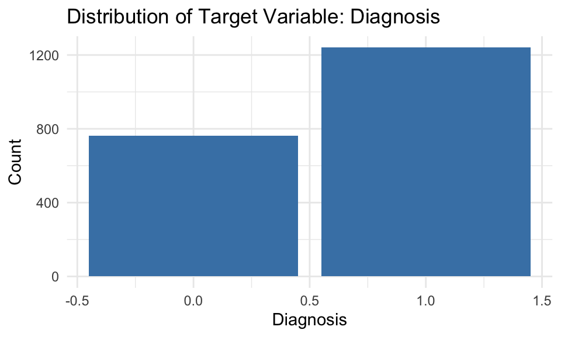

```r
target <- 'Diagnosis'
# Plot distribution of the target variable (class label)
ggplot(clean.train_df, aes(x = .data[[target]])) +
  geom_bar(fill = "steelblue") +
  labs(title = paste("Distribution of Target Variable:", target),
       x = target, y = "Count") +
  theme_minimal()
```

```r
target_dist <- table(clean.train_df$Diagnosis)
neg_per <- round(target_dist[1]/nrow(clean.train_df)*100,)
pos_per <- round(target_dist[2]/nrow(clean.train_df)*100,)
```

The graph above indicates a mild case of class imbalance. Class `0` (negative diagnosis) accounts for 38% of the dataset, while class `1` (positive diagnosis) represents 62%. This 38:62 split suggests a mild imbalance that should be considered when evaluating model performance, particularly with metrics such as the F1-score.

##### Numeric Features

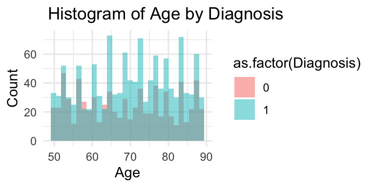

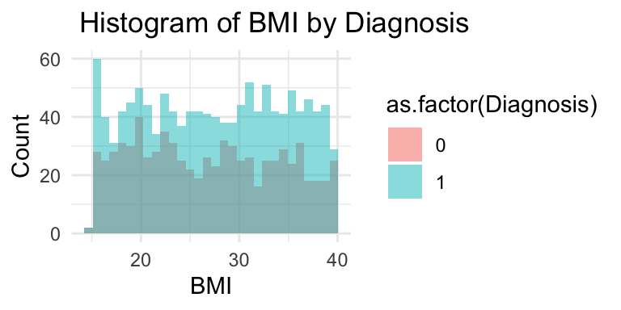

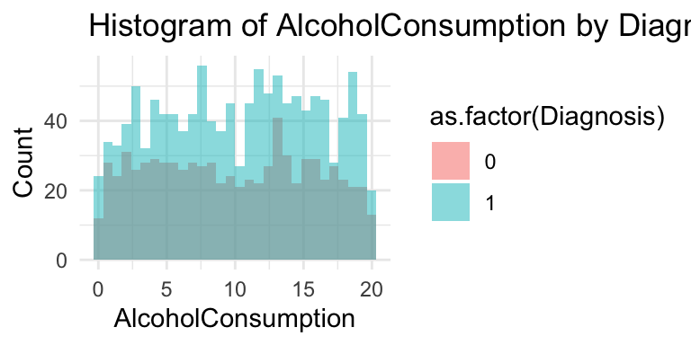

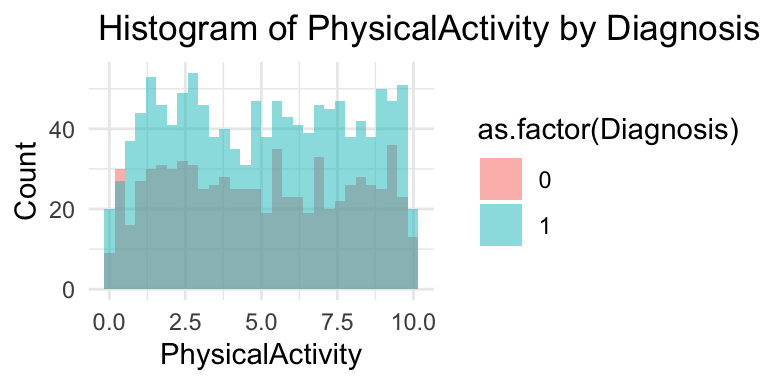

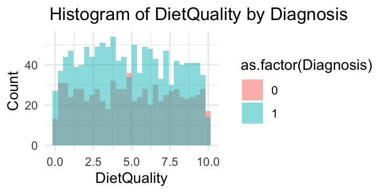

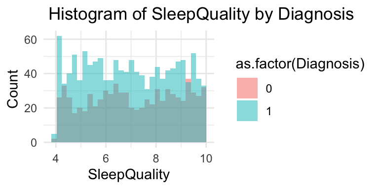

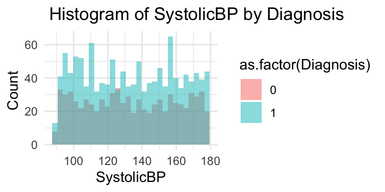

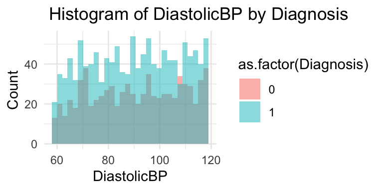

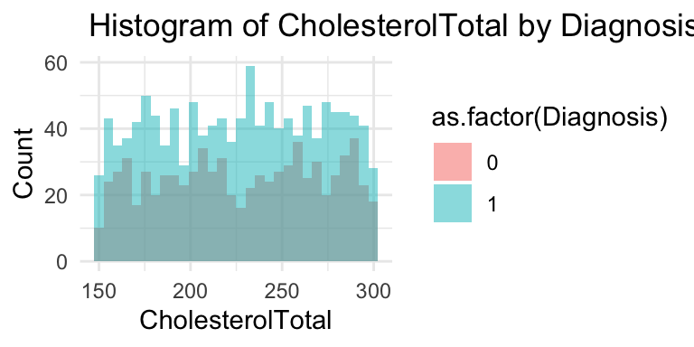

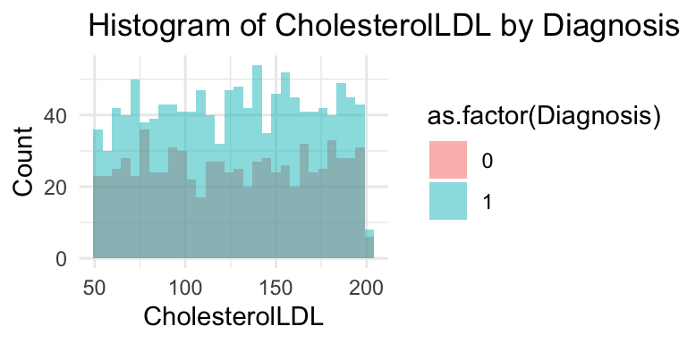

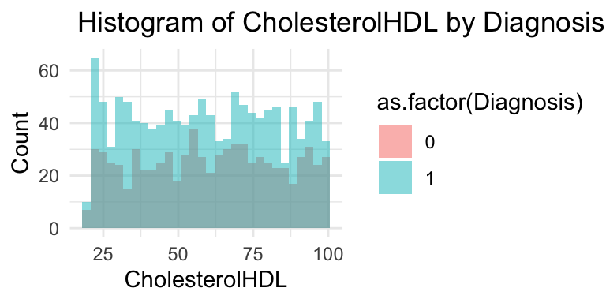

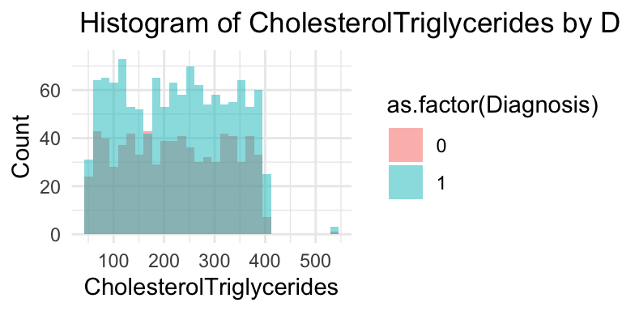

[3 more figures not shown]

```r
numeric_features <- names(rf_df)[sapply(rf_df, is.numeric)] # use rf_df bc num categorical has been factorized. For LR, they need to stay as num
# Plot numeric features using histograms (grouped by class label)
numericDist <- function (df, numeric_features, target, type=NULL){
  for (feature in numeric_features) {
    print(
      ggplot(df, aes(x = .data[[feature]], fill = as.factor(.data[[target]]))) +
        geom_histogram(position = "identity", alpha = 0.5, bins = 30) +
        labs(title = paste(type, "Histogram of", feature, "by", target),
             x = feature, y = "Count") +
        theme_minimal()
    )
  }
}

numericDist(clean.train_df, numeric_features, target)
```

The numeric features do not follow a normal distribution, although they do not exhibit significant skewness either. We will apply log and square root transformations to assess whether these can improve the distributional properties of the data.

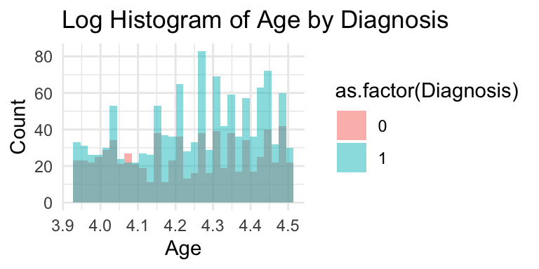

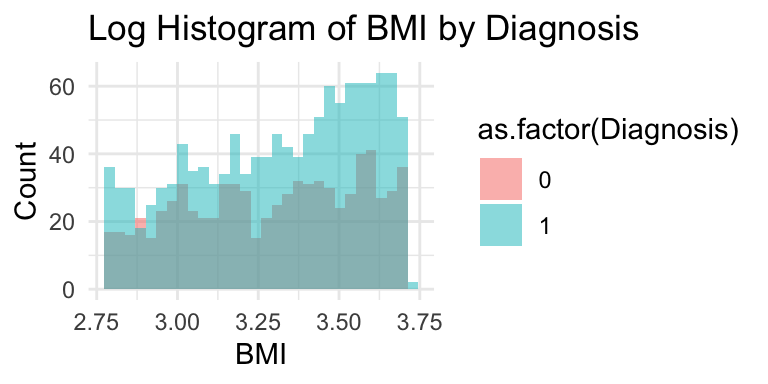

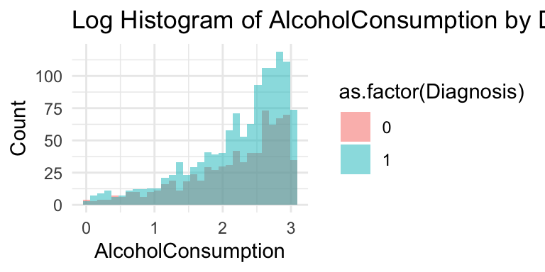

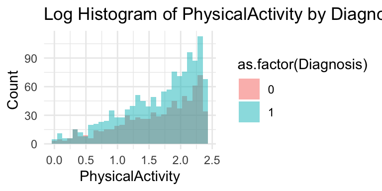

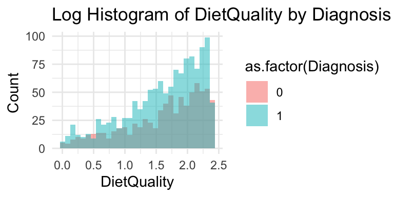

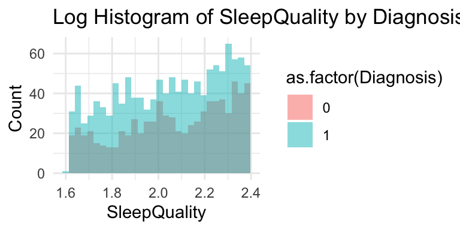

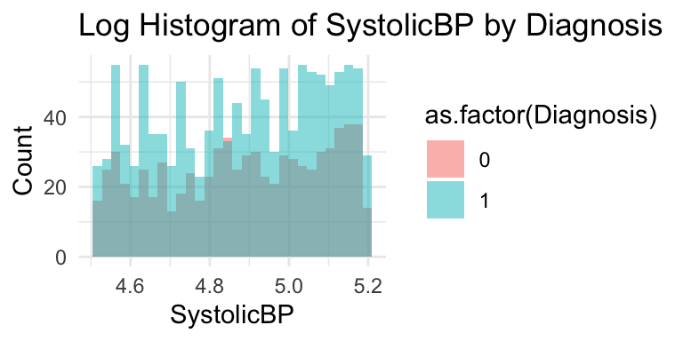

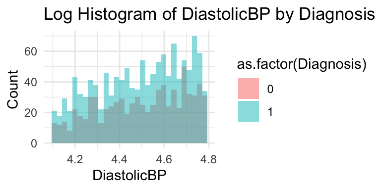

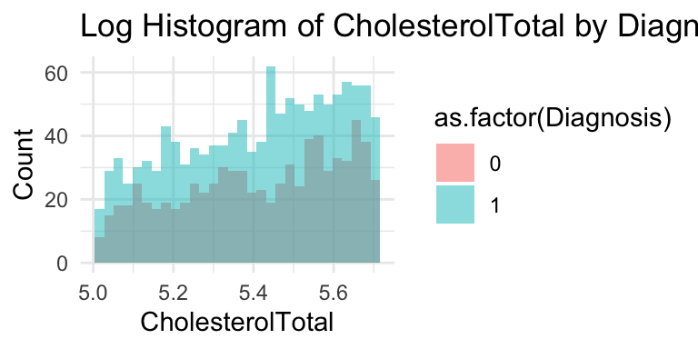

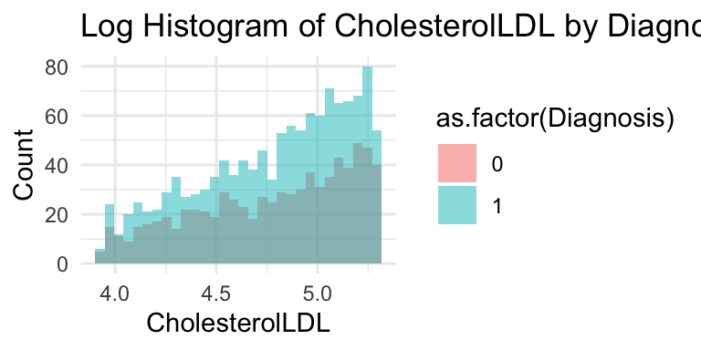

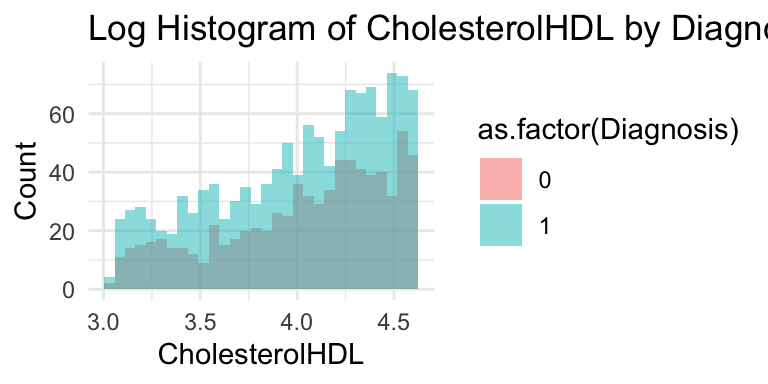

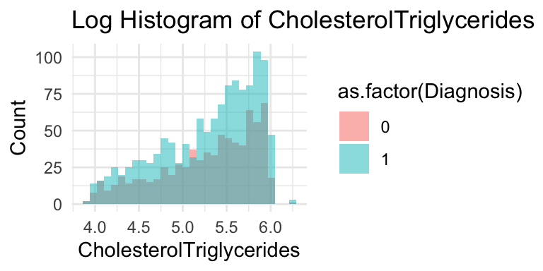

[3 more figures not shown]

```r
# create df for log transformed num feat for easy viewing
df_log <- rf_df %>%
  mutate(across(all_of(numeric_features), ~ log(.x + 1)))

# view dist
numericDist(df_log, numeric_features, target, "Log")
```

The log transformation causes the overall distribution of the data to become left-skewed. In this case, the original data exhibits a better distribution.